# Untitled

Cameron Bale

8/4/2020

Install and load packages.

```r
#install.packages(c("tidyverse", "igraph", "tidygraph", "here", "ggraph"))

library(tidyverse)
library(igraph)
library(tidygraph)
library(here)
library(ggraph)
```

Read in the data for the workshop. This is ‘fake’ network data based on a survey sent to workshop participants.

```r
wsd <- read_csv(here("data", "AnonSurveyData.csv"))
```

View data structure.

```r
glimpse(wsd)
```

```
## Rows: 34
## Columns: 18
## $ ID                      <dbl> 5106, 6633, 7599, 4425, 2495, 6355, 8810, 3...
## $ StartDate               <dttm> 2020-07-30 12:15:20, 2020-07-30 12:18:50, ...
## $ EndDate                 <dttm> 2020-07-30 12:18:59, 2020-07-30 12:20:21, ...
## $ Status                  <chr> "IP Address", "IP Address", "IP Address", "...
## $ Progress                <dbl> 100, 100, 100, 100, 100, 100, 100, 100, 100...
## $ `Duration (in seconds)` <dbl> 219, 91, 137, 97, 127, 233, 97, 144, 103, 2...
## $ Finished                <lgl> TRUE, TRUE, TRUE, TRUE, TRUE, TRUE, TRUE, T...
## $ RecordedDate            <dttm> 2020-07-30 12:18:59, 2020-07-30 12:20:22, ...
## $ SurveyID                <chr> "R_ssTGHZwy5EpQaNX", "R_2fv9VCk0tjdrDOr", "...
## $ ExternalReference       <lgl> NA, NA, NA, NA, NA, NA, NA, NA, NA, NA, NA,...
## $ DistributionChannel     <chr> "email", "email", "email", "email", "email"...
## $ UserLanguage            <chr> "EN", "EN", "EN", "EN", "EN", "EN", "EN", "...
## $ Q2                      <chr> "morning person.", "morning person.", "nigh...
## $ Q3                      <chr> "Brownies", "I don't care for dessert.", "I...
## $ Q4                      <chr> "Coffee,Water,The tears of my enemies", "Co...
## $ Q5                      <dbl> 350, 12, 300, 0, 264, 4, 289, 550, 349, 300...
## $ Q6                      <dbl> 350, 56, 5000, 50, 286, 250, 76, 185, 108, ...
## $ `as.character(Q5)`      <dbl> 350, 12, 300, 0, 264, 4, 289, 550, 349, 300...
```

Cut out some of the data, selecting variables of interest.

```r
wsd <- wsd %>%
  select(ID, Q2:Q6)
```

View selected variables.

```r
glimpse(wsd)
```

```
## Rows: 34
## Columns: 6
## $ ID <dbl> 5106, 6633, 7599, 4425, 2495, 6355, 8810, 3877, 1554, 7743, 8353...
## $ Q2 <chr> "morning person.", "morning person.", "night owl.", "morning per...
## $ Q3 <chr> "Brownies", "I don't care for dessert.", "Ice Cream", "I don't c...
## $ Q4 <chr> "Coffee,Water,The tears of my enemies", "Coffee,Tea,Water,Milk",...
## $ Q5 <dbl> 350, 12, 300, 0, 264, 4, 289, 550, 349, 300, 424, 426, 231, 290,...
## $ Q6 <dbl> 350, 56, 5000, 50, 286, 250, 76, 185, 108, 220, 500, 350, 412, 1...
```

### Data Exploration

We can perform some initial data exploration to get a feel for what this data looks like.

Compare whether people are `morning person` or `night owl`.

```r
wsd %>%
  select(Q2) %>%
  group_by(Q2) %>%
  tally()
```

```
## # A tibble: 2 x 2
##   Q2                  n
##   <chr>           <int>
## 1 morning person.    19
## 2 night owl.         15
```

Compare dessert preferences.

```r
wsd %>%
  select(Q3) %>%
  group_by(Q3) %>%
  tally()
```

```
## # A tibble: 5 x 2
##   Q3                                      n
##   <chr>                               <int>
## 1 Brown Butter Chocolate Chip Cookies     2
## 2 Brownies                                9
## 3 Cheese                                  3
## 4 I don't care for dessert.               3
## 5 Ice Cream                              17
```

Visualization is sometimes easier to process than a table of numbers.

Plot dessert preferences.

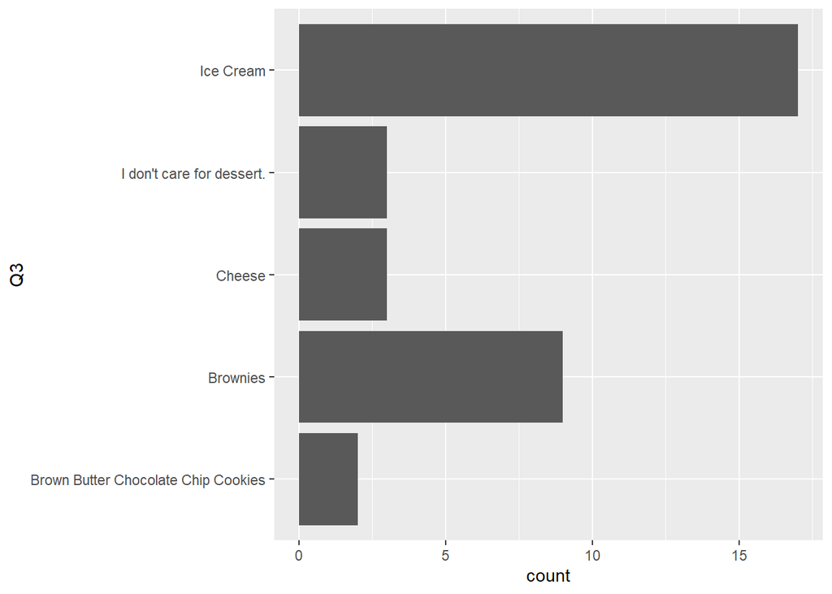

```r
wsd %>%
  select(Q3) %>%
  ggplot(aes(y = Q3)) +
  geom_bar()
```

Compare individuals’ drinks. This isn’t `tidy` data, since there are multiple values per entry in one variable.

```r
wsd %>%
  select(ID, Q4) %>%
  head()
```

```
## # A tibble: 6 x 2
##      ID Q4
##   <dbl> <chr>
## 1  5106 Coffee,Water,The tears of my enemies
## 2  6633 Coffee,Tea,Water,Milk
## 3  7599 Fruit Juice,Tea,Water,Fizzy Water
## 4  4425 Fruit Juice,Coffee,Water
## 5  2495 Coffee,Water
## 6  6355 Fruit Juice,Tea,Water
```

There is a command `separate_rows` which can easily handle this.

```r
wsd %>%
  select(ID, Q4) %>%
  separate_rows(Q4, sep = ',') %>%
  head(10)
```

```
## # A tibble: 10 x 2
##       ID Q4
##    <dbl> <chr>
##  1  5106 Coffee
##  2  5106 Water
##  3  5106 The tears of my enemies
##  4  6633 Coffee
##  5  6633 Tea
##  6  6633 Water
##  7  6633 Milk
##  8  7599 Fruit Juice
##  9  7599 Tea
## 10  7599 Water
```

We can combine the `separate_rows` command with `pivot_wider` to create indicator variables for each of the drink types.

```r
wsd %>%
  select(ID, Q4) %>%
  separate_rows(Q4, sep = ',') %>%
  mutate(Checked = 1) %>%
  pivot_wider(names_from = Q4,
              values_from = Checked,
              values_fill = 0)
```

```
## # A tibble: 34 x 11
##       ID Coffee Water `The tears of m~   Tea  Milk `Fruit Juice` `Fizzy Water`
##    <dbl>  <dbl> <dbl>            <dbl> <dbl> <dbl>         <dbl>         <dbl>
##  1  5106      1     1                1     0     0             0             0
##  2  6633      1     1                0     1     1             0             0
##  3  7599      0     1                0     1     0             1             1
##  4  4425      1     1                0     0     0             1             0
##  5  2495      1     1                0     0     0             0             0
##  6  6355      0     1                0     1     0             1             0
##  7  8810      1     0                1     0     0             0             1
##  8  3877      0     1                1     1     1             0             1
##  9  1554      0     1                1     0     0             1             0
## 10  7743      0     1                0     1     1             1             1
## # ... with 24 more rows, and 3 more variables: `A delicious 12 year single malt
## #   scotch from the Scottish lowlands with notes of apple` <dbl>, `
## #   cinnamon` <dbl>, ` and dried fruit served with a single ice cube` <dbl>
```

We can look at cross tabulations of multiple variables, such as the number of pages in the last book individuals read by whether they are a `morning person` or a `night owl`.

```r
wsd %>%
  select(Q2, Q5) %>%
  group_by(Q2) %>%
  summarize(Ave = mean(Q5),
            SD = sd(Q5))
```

```
## # A tibble: 2 x 3
##   Q2                Ave    SD
##   <chr>           <dbl> <dbl>
## 1 morning person.  321   215.
## 2 night owl.       335.  289.
```

Again, this can be plotted.

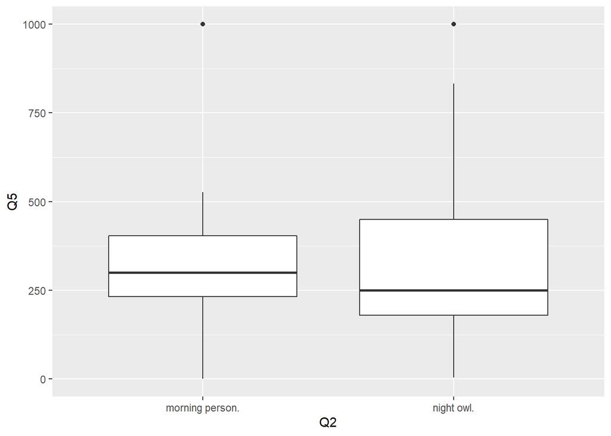

```r
wsd %>%
  select(Q2, Q5) %>%
  ggplot(aes(x = Q2, y = Q5)) +
  geom_boxplot()
```

### Prep for SNA

Read in the edge list data. This shows all the people from the workshop that individuals who took the survey said they were connected to.

```r
EL <- read_csv(here('data', 'AnonEL.csv'))
```

Some individuals only have one connection, others have several.

```r
EL %>%
  arrange(ID) %>%
  head(10)
```

```
## # A tibble: 10 x 2
##       ID Connections
##    <dbl>       <dbl>
##  1  1367        1651
##  2  1386        7743
##  3  1386        1554
##  4  1386        8575
##  5  1386        2169
##  6  1386        1958
##  7  1386        9929
##  8  1386        1386
##  9  1554        7743
## 10  1554        8575
```

We need to assemble the attributes from the survey that we want to attach to nodes.

```r
attdf <- wsd %>%
  select(ID, Q2, Q3, Q5)
```

We can plot the network.

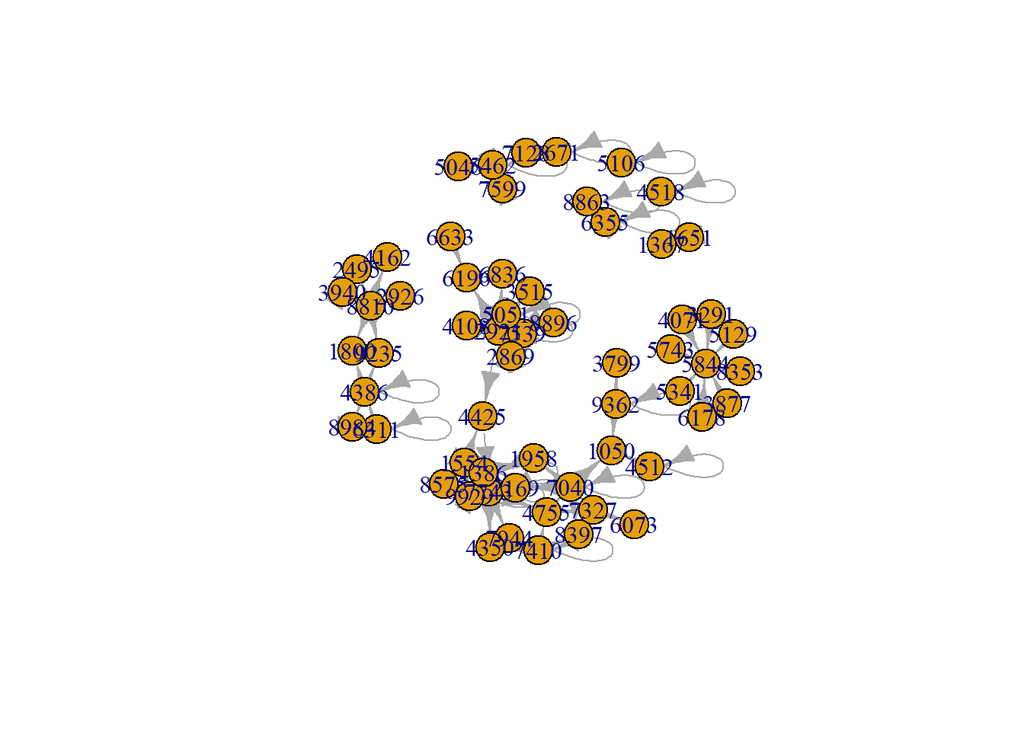

```r
gr <- graph_from_data_frame(EL, directed = TRUE)

plot(gr)
```

And, we can convert the plot to be `tidyverse` compatible.

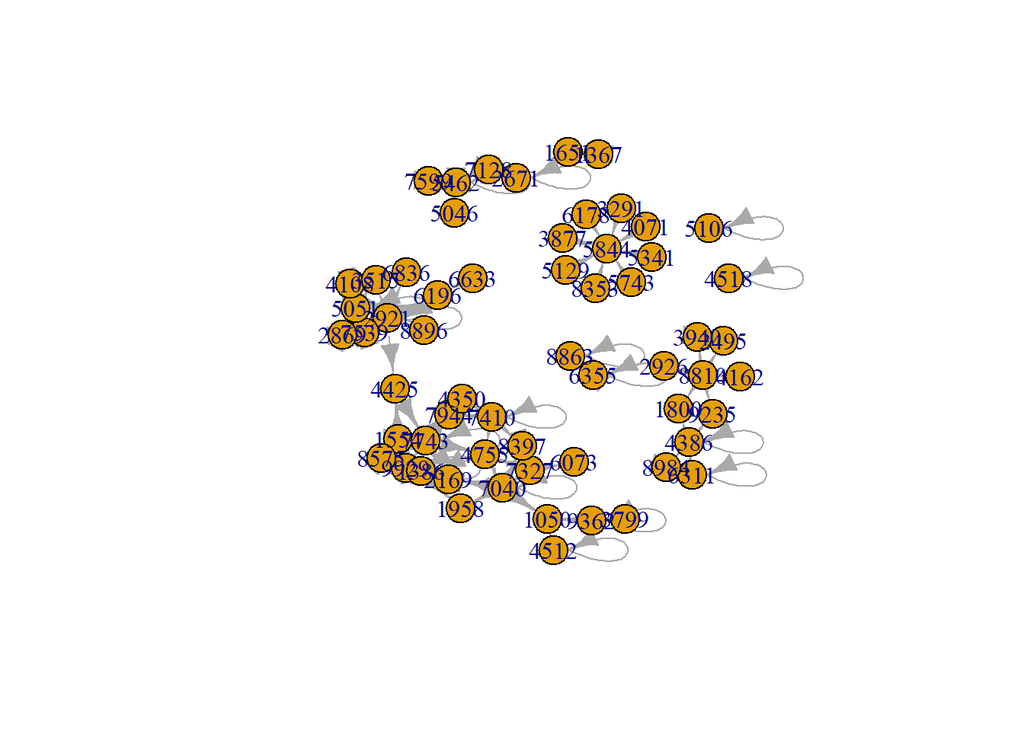

```r
gr <- as_tbl_graph(gr)

plot(gr)
```

Easiest way to add the attributes is the add them while making the graph. However, our graph contains individuals who did not take the survey, but that were reported as known by people who did take the survey. So, our attributes won’t match up to the number of individuals at this point. We can fix this.

```r
#gr %>%
#  activate(nodes) %>%
#  mutate(AMPM = attdf$Q2)
```

First, we take our graph and change the variable `name` to `ID`, making sure that `ID` is a numeric variable. This gives us one variable with one entry for each person in the network.

```r
grnodes <- gr %>%
  activate(nodes) %>%
  as_tibble() %>%
  transmute(ID = name) %>%
  mutate(ID = as.numeric(ID))
```

We join the attributes from the attribute data to the graph ID’s. This puts `NA` for the attributes of everyone who did not take the survey but was reported as a connection.

```r
nodeatts <- left_join(grnodes, attdf, by = 'ID')
```

We check that our work looks correct.

```r
head(nodeatts)
```

```
## # A tibble: 6 x 4
##      ID Q2              Q3                           Q5
##   <dbl> <chr>           <chr>                     <dbl>
## 1  5106 morning person. Brownies                    350
## 2  6633 morning person. I don't care for dessert.    12
## 3  7599 night owl.      Ice Cream                   300
## 4  4425 morning person. I don't care for dessert.     0
## 5  2495 morning person. Brownies                    264
## 6  6355 night owl.      Ice Cream                     4
```

As expected, the people who did not take the survey have `NA` values for their attributes.

```r
tail(nodeatts)
```

```
## # A tibble: 6 x 4
##      ID Q2    Q3       Q5
##   <dbl> <chr> <chr> <dbl>
## 1  7128 <NA>  <NA>     NA
## 2  1050 <NA>  <NA>     NA
## 3  3799 <NA>  <NA>     NA
## 4  1651 <NA>  <NA>     NA
## 5  8984 <NA>  <NA>     NA
## 6  1958 <NA>  <NA>     NA
```

Re-attempt to assemble the graph. Everything seems to have worked. The output below indicates there are four attributes applied to vertices, and they are either character or numeric attributes.

```r
gr <- gr %>%
  as_tbl_graph() %>%
  activate(nodes) %>%
  mutate(AMPM = nodeatts$Q2,
         Dessert = nodeatts$Q3,
         Pages = nodeatts$Q5)

summary(gr)
```

```
## IGRAPH b18ab91 DN-- 60 101 --
## + attr: name (v/c), AMPM (v/c), Dessert (v/c), Pages (v/n)
```

View `gr` graph object.

```r
gr
```

```
## # A tbl_graph: 60 nodes and 101 edges
## #
## # A directed multigraph with 8 components
## #
## # Node Data: 60 x 4 (active)
##   name  AMPM            Dessert                   Pages
##   <chr> <chr>           <chr>                     <dbl>
## 1 5106  morning person. Brownies                    350
## 2 6633  morning person. I don't care for dessert.    12
## 3 7599  night owl.      Ice Cream                   300
## 4 4425  morning person. I don't care for dessert.     0
## 5 2495  morning person. Brownies                    264
## 6 6355  night owl.      Ice Cream                     4
## # ... with 54 more rows
## #
## # Edge Data: 101 x 2
##    from    to
##   <int> <int>
## 1     1     1
## 2     2    35
## 3     3    14
## # ... with 98 more rows
```

### Plotting Graph

Most basic plot of network.

```
## Using `stress` as default layout
```

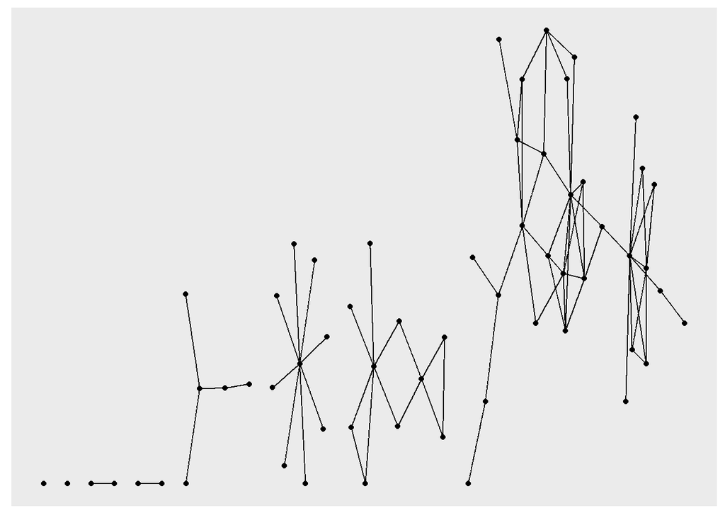

```r
gr %>%
  ggraph() +
  geom_edge_link() +
  geom_node_point()
```

Can change the layout to be more appealing.

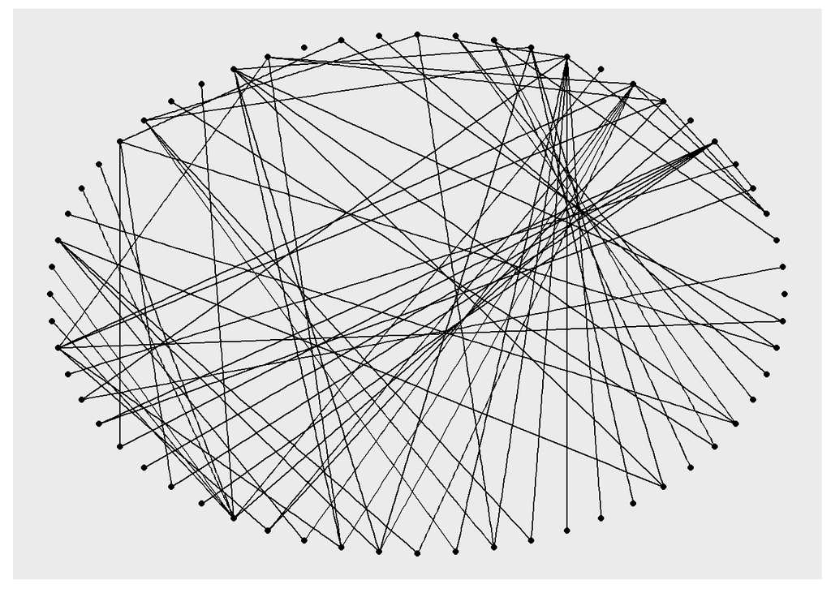

```r
gr %>%
  ggraph(layout = 'circle') +
  geom_edge_link() +
  geom_node_point()
```

We can change the shape of the points to be meaningful, e.g. to represent whether someone is a `morning person` or a `night owl`. There are also `NA` values, as expected.

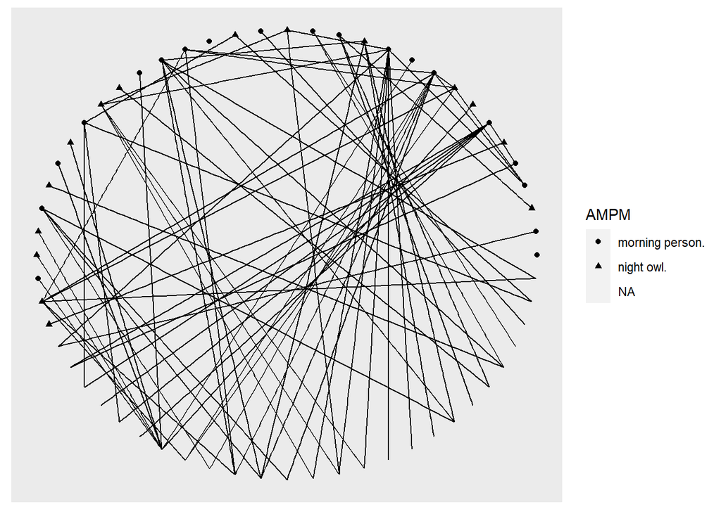

```r
gr %>%
  ggraph(layout = 'circle') +
  geom_edge_link() +
  geom_node_point(aes(shape = AMPM))
```

The color of points can also be meaningful, e.g. the color represents individuals’ dessert preferences.

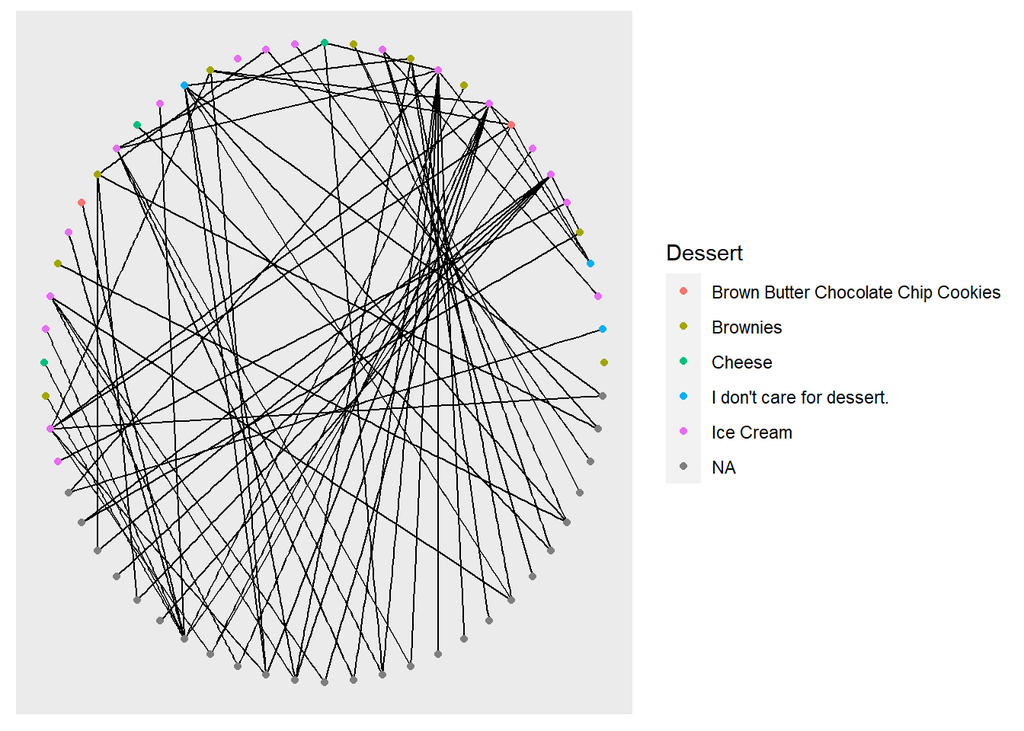

```r
gr %>%
  ggraph(layout = 'circle') +
  geom_edge_link() +
  geom_node_point(aes(color = Dessert))
```

The size of points can be meaningful, e.g. the number of pages in the last book an individual read.

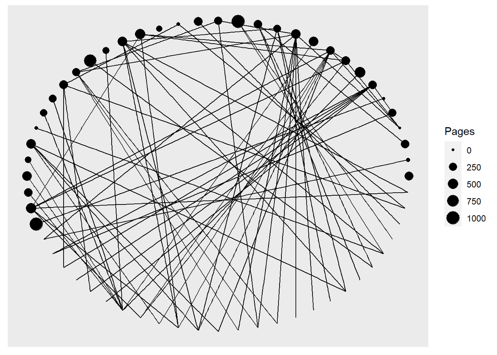

```r
gr %>%
  ggraph(layout = 'circle') +
  geom_edge_link() +
  geom_node_point(aes(size = Pages))
```

Finally, we can combine all of these attributes into one plot, although it may be a little busy.

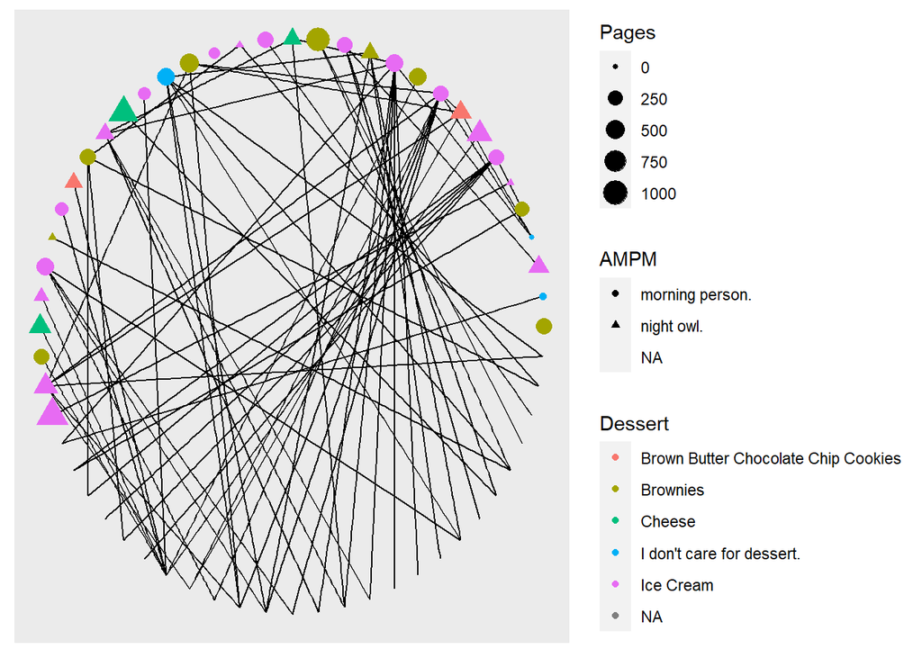

```r
gr %>%
  ggraph(layout = 'circle') +
  geom_edge_link() +
  geom_node_point(aes(shape = AMPM,
                      color = Dessert,
                      size = Pages))
```